# AQI Category Agreement Analysis Tutorial

This tutorial walks through the *‘template_for_sensor_vs_monitor.R’* script located in the `FASM-sensor-AQI-analysis/R` folder using example air sensor data. It describes the steps and functions used to generate the AQI category agreement bar plots used as part of the evaluations for new sensors seeking to be displayed on the AirNow Fire and Smoke Map.

# Set Up

This makes sure the necessary packages are installed and loaded and that the functions are called in from their source script *‘functions_for_AQI_barplots.R’*. Note that this tutorial and the template script use the `here` package to work with file paths in this repository. The `here` package constructs paths relative to the project root. Ensure that the current working directory or the project root is set to `FASM-sensor-AQI-analysis`. This can be done in the Files tab of the Files/Plots/Packages/Help pane of RStudio. Navigate to the `FASM-sensor-AQI-analysis` directory. Click **More > Set As Working Directory**. The `setwd()` function can also be used to set the working directory.

```r
# Ensure 'here' package is installed
if (!requireNamespace("here", quietly = TRUE)) install.packages("here")
library(here)

# Source requirements to load necessary packages and configurations
source(here("R/package_requirements.R"))
# Ensure the working directory or the project root is set to FASM-sensor-AQI-analysis

# Load utility functions from 'functions_for_AQI_barplots.R'
source(here("R/functions_for_AQI_barplots.R"))
# Ensure the working directory or the project root is set to FASM-sensor-AQI-analysis
```

# Sensor Data Prep

Next, load in your sensor data and use it to create the *mts_monitor* object that will be used for comparison against the AirNow reference monitors. This tutorial uses some example sensor data, which can also be used to help understand the required data format for your own sensor data. Ensure your data is in **UTC** time; the example data has already been converted to UTC time stamps. This first example uses nationwide public Clarity Movement Co. sensor data from May 30, 2023 through September 29, 2023. Thank you to Clarity for providing these data via EPA MTA 1643-25 / FS MTA 25-RD-11132543-061.

```r
# Ensure your metadata and time-series data files are saved in the data folder of the repository
# (where some examples are already located)

# Load in sensor data (recommend using 'read_csv' rather than 'read.csv')
meta_df <- read_csv(here("data/clarity_meta.csv"))
# input metadata file name from data folder ("clarity_meta.csv" in this example)

# Ensure metadata columns are the correct class
meta_df$deviceDeploymentID <- as.character(meta_df$deviceDeploymentID)
meta_df$deviceID <- as.character(meta_df$deviceID)
meta_df$locationID <- as.character(meta_df$locationID)
meta_df$locationName <- as.character(meta_df$locationName)
meta_df$longitude <- as.numeric(meta_df$longitude)
meta_df$latitude <- as.numeric(meta_df$latitude)
meta_df$elevation <- as.numeric(meta_df$elevation)
meta_df$countryCode <- as.character(meta_df$countryCode)
meta_df$stateCode <- as.character(meta_df$stateCode)
meta_df$countyName <- as.character(meta_df$countyName)
meta_df$timezone <- as.character(meta_df$timezone)

data_df <- read_csv(here("data/clarity_data.csv"))
# input time-series data file name from data folder ("clarity_data.csv" in this example)

# Create mts_monitor object
sensor <- list(meta = meta_df,
               data = data_df)

sensor <- structure(sensor,
                    class = c("mts_monitor", "mts", class(sensor)))
```

## Important Requirements for Sensor Data

The sensor data must consist of two files (.csv or .xlsx format), one of metadata and one of time-series data that will be combined into a *mts_monitor* object for analysis. To read more about the *mts_monitor* data format, see https://mazamascience.github.io/MazamaTimeSeries/.

### Sensor Metadata

The metadata file must have each row as a unique device and columns of device metadata.

- Required columns must include (written and titled **exactly** as below):
  - *deviceDeploymentID*
  - *deviceID*
  - *locationID*
  - *locationName*
  - *longitude*
  - *latitude*
  - *elevation*
  - *countryCode*
  - *stateCode*
  - *countyName*
  - *timezone*
- All columns are of class character except *longitude*, *latitude*, and *elevation* which are of class numeric.
- The *elevation* and *timezone* columns must exist for functions to run, but aren’t required to be populated (can be left blank).
- *deviceDeploymentID*, *deviceID*, and *locationID* are character identifiers for the sensors. *locationID* is typically generated from the latitude/longitude data, *deviceID* is an identification for the sensor, and *deviceDeploymentID* is a combination of the *locationID* and *deviceID*.
- Any additional metadata columns beyond those listed above can be included.

### Sensor Time-series Data

The time-series data file must have each row as an hourly **UTC** timestamp (with date and time) and columns of the measured parameter for each device, plus the first column for the timestamps.

- The column titles must be:
  - *datetime*
  - the *deviceDeploymentID* used in the metadata

**IMPORTANT**: The order of the *deviceDeploymentID* down the rows of the metadata must match the order of the *deviceDeploymentID* across the columns of the time-series data after the datetime column.

- For example, if sensor123abc is the first row in the metadata, then sensor123abc must also be the second column in the time-series data after the datetime column. If sensor456def is the second row in the metadata, then sensor456def must also be the third column in the time-series data after the datetime column and the first sensor.

# Reference AirNow Data

Data from AirNow can easily be loaded in for specific windows of time using the `monitor_load` function from the `AirMonitor` package, and loads in with **UTC** time stamps. Code is provided to select a start and end date to match your sensor data; any missing data within the start and end dates are irrelevant. Note that this could take a few minutes depending on how much data you’re trying to load.

```r
# Extract the start and end date from the sensor data
startdate <- format(as.Date(min(sensor$data$datetime)), "%Y%m%d")
enddate <- format(as.Date(max(sensor$data$datetime)), "%Y%m%d")

# Load in AirNow data for the specified date range
airnow <- monitor_load(
  startdate = startdate,  # input start and end date to match sensor data
  enddate = enddate       # format example if input manually: startdate = 20210601
)
```

Data might need to be trimmed slightly for start and end timestamps to match. Code is provided to find the overlapping time period between the sensor data and the AirNow data and filter both to match the overlapping periods.

```r
# Find a common start and end datetime stamp between the AirNow and sensor data
aligned_startdate <- max(min(airnow$data$datetime), min(sensor$data$datetime))
aligned_enddate <- min(max(airnow$data$datetime), max(sensor$data$datetime))

# Filter the data to the overlapping datetime stamps
airnow$data <- airnow$data[airnow$data$datetime >= aligned_startdate & airnow$data$datetime <= aligned_enddate, ]
sensor$data <- sensor$data[sensor$data$datetime >= aligned_startdate & sensor$data$datetime <= aligned_enddate, ]
```

# Find Adjacent Pairs

Now that data is loaded, you can use the `findAdjacentPairs` function to find sensors that are within a specified radius of nearby AirNow monitors. The proposed radius for analysis is 1000 meters, but this can be easily adjusted in the `findAdjacentPairs` function to find nearby sensor/monitor pairs within any desired radius in meters. This function adds two columns to the sensor metadata: the *airnow_closestDistance* and the *airnow_id* to identify the nearest AirNow monitor to the sensor within the specified radius. The following warning may appear when this function is used and can be ignored: “number of items to replace is not a multiple of replacement length.” The AirNow data is then filtered to retain the monitors identified as nearby the sensors, and the PM2.5 NowCast algorithm is applied so that data are most representative of how they are displayed on the Fire and Smoke map. To read more about the `monitor_nowcast` function and the NowCast algorithm, see https://mazamascience.github.io/AirMonitor/articles/NowCast.html and/or visit https://www.epa.gov/sites/default/files/2018-01/documents/nowcastfactsheet.pdf.

```r
# Returns mts_monitor object of sensors within specified radius of reference monitors
sensor_adjacent <- findAdjacentPairs(sensor = sensor,
                                     airnow = airnow,
                                     1000)    # specify the radius in meters

# Call out the ids of the adjacent pairs
airnow_ids <- unique(sensor_adjacent$meta$airnow_id)
sensor_ids <- unique(sensor_adjacent$meta$deviceDeploymentID)

# Filter the airnow data set for adjacent pairs
airnow_adjacent <-
  airnow %>%
  monitor_select(airnow_ids)

# Apply the NowCast algorithm
sensor_adjacent <-
  sensor_adjacent %>%
  monitor_nowcast(includeShortTerm = TRUE)

airnow_adjacent <-
  airnow_adjacent %>%
  monitor_nowcast(includeShortTerm = TRUE)
```

# Map Adjacent Pairs

It can be helpful to visualize geographically where the nearby sensor/monitor pairs are located across the county. The MazamaLocationUtils package includes leaflet functions for mapping devices with latitude and longitude information. This series of functions starts be making a map object of the AirNow monitors, then adds the nearby sensors to the map. It includes a title which counts the number of AirNow monitors and nearby sensors. Keep in mind that one AirNow monitor may have more than one sensor within the specified nearby radius.

```r
# This starts by creating a leaflet map of just the airnow monitors
map <- MazamaLocationUtils::table_leaflet(
  airnow_adjacent$meta,
  jitter = 0
)

# Then add the nearby sensors to the map object
MazamaLocationUtils::table_leafletAdd(
  map,
  sensor_adjacent$meta,
  jitter = 0,
  fillColor = "salmon",
  color = "black"
) %>%

  # Then add a title which include a count of monitors and their nearby sensor pairs
  leaflet::addControl(
    html = paste0("<h3>Mapped locations of ", nrow(airnow_adjacent$meta), " AirNow monitors and ", nrow(sensor_adjacent$meta), " nearby sensors", "</h3>"),
    position = "topright")
```

[interactive chart not shown]

# List Adjacent Pairs

It could also be useful to print a table of the paired sensor/AirNow monitors IDs to easily identify which sensors are nearby which monitors. The below code selects the *deviceDeploymentID* and the *airnow_id* columns from the meta data dataframe of the “sensor_adjacent” list to print a table of the paired nearby sensor/monitor IDs.

```r
sensor_adjacent$meta %>%
  select(deviceDeploymentID, airnow_id) %>%
  datatable(              # function for creating an interactive table
    options = list(
      pageLength = 25,    # edit how many rows should appear in a table page
      scrollX = TRUE      # include a horizontal scroll bar on the table
    ),
    rownames = FALSE
  )
```

| deviceDeploymentID | airnow_id |
| --- | --- |
| 9q962hdgky_clarity.DELSW4166 | 7a875733f97e23b0_840060870007 |
| 9q94vgju3n_clarity.DPFCG6807 | 71d8ec363f0b8318_840060871005 |
| dhvr535e00_clarity.DRQPE4506 | dhvr535_840120570113 |
| 9qcee1eyb1_clarity.DCYKE1986 | 365882eb5497ada3_840060670015 |
| 9qce7m5rxr_clarity.DNCIT5626 | 127e996697f9731c_840060670010 |
| 9q3vgxwubq_clarity.DCTWX0734 | 027b1c6b135d09ba_840060530008 |
| 9qcee1geew_clarity.DPEKF6273 | 365882eb5497ada3_840060670015 |
| 9q9j5pw0wz_clarity.DSQLA2803 | 204520f83a9742d6_840060811001 |
| 9q8yyepgcs_clarity.DYTNX2136 | fa7ae26987a72cc4_840060750005 |
| 9qbmz5vrhh_clarity.DVJAA6291 | 06408f50e03b9f65_arb3.2010 |

[output cut: 8 more lines]

# Unlisted AQI Category Data Frame

The `create_AQI_unlisted` function returns a data frame named “AQI_unlisted” with two columns, *airnow* and *sensor*. This is the PM2.5 NowCast AQI category for each hour where the sensor and AirNow monitor pairs both have data. The AQI categories are represented as numbers, as described in the table below. To read more about the AQI categories, see https://www.airnow.gov/aqi/aqi-basics/.

| AQI Category | Number Assignment |
| --- | --- |
| Good | 1 |
| Moderate | 2 |
| Unhealthy for Sensitive Groups | 3 |
| Unhealthy | 4 |
| Very Unhealthy | 5 |
| Hazardous | 6 |

```r
AQI_unlisted <- create_AQI_unlisted(sensor_adjacent = sensor_adjacent,
                                    airnow_adjacent = airnow_adjacent)
```

# Overall AQI Category Agreement Bar Plot

The `create_combined_barplot` function accepts the `AQI_unlisted` data frame and returns a bar plot comparing AQI category agreement between the sensors and AirNow monitors across all AQI categories combined. You can specify the position of horizontal dashed lines where thresholds for agreement can be visualized. Thresholds can be shown for plus/minus one AQI category and plus/minus two or more AQI categories. Currently, the proposed thresholds for plus/minus one AQI category is no more than **5%** of the time and plus/minus two or more AQI categories no more than **1%** of the time.

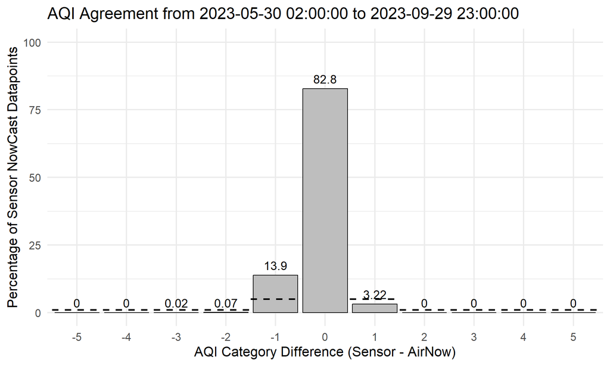

```r
create_combined_barplot(AQI_unlisted = AQI_unlisted,
                        threshold_1 = 5,
                        # input the threshold for plus/minus one AQI category (default is 5)
                        threshold_2 = 1
                        # input the threshold for plus/minus two or more AQI categories (default is 1)
                        )
```

# AQI Category Agreement Bar Plot Grid

The `create_plots_by_category` function accepts the `AQI_unlisted` data frame and returns a figure that shows AQI category agreement by AQI category reported by the reference monitor data. For example, when AirNow monitors are reporting Moderate, what AQI categories are reported by nearby sensors? This function must also be told the number of plots to show via the `num_plots` variable, which is based on the maximum AQI category reported by the AirNow monitor reference data. For example, if your AirNow monitor reference data reaches the Unhealthy AQI category, four bar plots will be arranged in the figure. Code is provided to determine how many plots should be arranged in the figure. As above, thresholds can be shown for plus/minus one AQI category and plus/minus two or more AQI categories. Currently, the proposed threshold for plus/minus one AQI category is no more than **30%** of the time and plus/minus two or more AQI categories no more than **1%** of the time within each AQI category reported by the reference monitors.

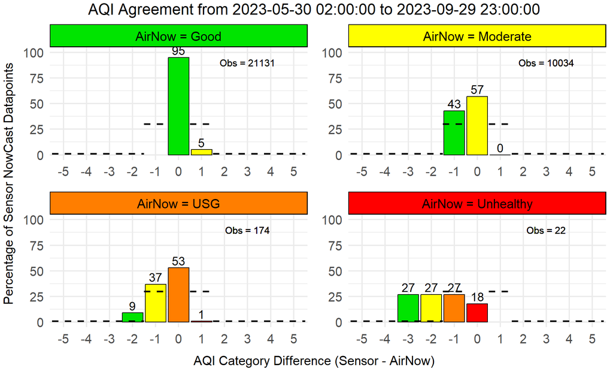

```r
# With this example Clarity data, the max AQI category from reference monitors is Unhealthy,
# so four bar plots are displayed
create_plots_by_category(AQI_unlisted = AQI_unlisted,
                         num_plots = max(AQI_unlisted$airnow),
                         # determine the maximum AQI category reported by AirNow
                         threshold_1 = 30,
                         # input the threshold for plus/minus one AQI category (default is 30)
                         threshold_2 = 1
                         # input the threshold for plus/minus two or more AQI categories (default is 1)
                         )
```

# Tabular Data

A table of hourly AQI category agreements can also be useful. The base R `table` function accepts the columns and rows for a table to output a table of hourly counts of AQI category agreements.

```r
tab <- table(
  "Sensor" = AQI_unlisted$sensor, # makes the sensor AQI categories the rows
  "Monitor" = AQI_unlisted$airnow # makes the monitor AQI categories the columns
)

addmargins(tab) # includes sums of all rows and columns
```

```
##       Monitor
## Sensor     1     2     3     4   Sum
##    1   20154  4288    16     6 24464
##    2     977  5716    64     6  6763
##    3       0    30    92     6   128
##    4       0     0     2     4     6
##    Sum 21131 10034   174    22 31361
```

# Example 2: PurpleAir

```r
# Ensure 'here' package is installed
if (!requireNamespace("here", quietly = TRUE)) install.packages("here")
library(here)

# Source requirements to load necessary packages and configurations
source(here("R/package_requirements.R"))
# Ensure the working directory or the project root is set to FASM-sensor-AQI-analysis

# Load utility functions from 'functions_for_AQI_barplots.R'
source(here("R/functions_for_AQI_barplots.R"))
# Ensure the working directory or the project root is set to FASM-sensor-AQI-analysis
```

## Sensor Data Prep

```r
# Load in sensor data (recommend using 'read_csv' rather than 'read.csv')
meta_df <- read_csv(here("data/purpleair_meta.csv"))
# input metadata file name from data folder ("purpleair_meta.csv" in this example)

# Ensure metadata columns are the correct class
meta_df$deviceDeploymentID <- as.character(meta_df$deviceDeploymentID)
meta_df$deviceID <- as.character(meta_df$deviceID)
meta_df$locationID <- as.character(meta_df$locationID)
meta_df$locationName <- as.character(meta_df$locationName)
meta_df$longitude <- as.numeric(meta_df$longitude)
meta_df$latitude <- as.numeric(meta_df$latitude)
meta_df$elevation <- as.numeric(meta_df$elevation)
meta_df$countryCode <- as.character(meta_df$countryCode)
meta_df$stateCode <- as.character(meta_df$stateCode)
meta_df$countyName <- as.character(meta_df$countyName)
meta_df$timezone <- as.character(meta_df$timezone)

data_df <- read_csv(here("data/purpleair_data.csv"))
# input time-series data file name from data folder ("purpleair_data.csv" in this example)

# Create mts_monitor object
sensor <- list(meta = meta_df,
               data = data_df)

sensor <- structure(sensor,
                    class = c("mts_monitor", "mts", class(sensor)))
```

## Reference AirNow Data

```r
# Extract the start and end date from the sensor data
startdate <- format(as.Date(min(sensor$data$datetime)), "%Y%m%d")
enddate <- format(as.Date(max(sensor$data$datetime)), "%Y%m%d")

# Load in AirNow data for the specified date range
airnow <- monitor_load(
  startdate = startdate,  # input start and end date to match sensor data
  enddate = enddate       # format example if input manually: startdate = 20210601
)

# Find a common start and end datetime stamp between the AirNow and sensor data
aligned_startdate <- max(min(airnow$data$datetime), min(sensor$data$datetime))
aligned_enddate <- min(max(airnow$data$datetime), max(sensor$data$datetime))

# Filter the data to the overlapping datetime stamps
airnow$data <- airnow$data[airnow$data$datetime >= aligned_startdate & airnow$data$datetime <= aligned_enddate, ]
sensor$data <- sensor$data[sensor$data$datetime >= aligned_startdate & sensor$data$datetime <= aligned_enddate, ]
```

## Find Adjacent Pairs

```r
# Returns mts_monitor object of sensors within specified radius of reference monitors
sensor_adjacent <- findAdjacentPairs(sensor = sensor,
                                     airnow = airnow,
                                     1000)    # specify the radius in meters

# Call out the ids of the adjacent pairs
airnow_ids <- unique(sensor_adjacent$meta$airnow_id)
sensor_ids <- unique(sensor_adjacent$meta$deviceDeploymentID)

# Filter the airnow data set for adjacent pairs
airnow_adjacent <-
  airnow %>%
  monitor_select(airnow_ids)

# Apply the NowCast algorithm
sensor_adjacent <-
  sensor_adjacent %>%
  monitor_nowcast(includeShortTerm = TRUE)

airnow_adjacent <-
  airnow_adjacent %>%
  monitor_nowcast(includeShortTerm = TRUE)
```

## Map Adjacent Pairs

```r
# This starts by creating a leaflet map of just the airnow monitors
map <- MazamaLocationUtils::table_leaflet(
  airnow_adjacent$meta,
  jitter = 0
)

# Then add the nearby sensors to the map object
MazamaLocationUtils::table_leafletAdd(
  map,
  sensor_adjacent$meta,
  jitter = 0,
  fillColor = "salmon",
  color = "black"
) %>%

  # Then add a title which include a count of monitors and their nearby sensor pairs
  leaflet::addControl(
    html = paste0("<h3>Mapped locations of ", nrow(airnow_adjacent$meta), " AirNow monitors and ", nrow(sensor_adjacent$meta), " nearby sensors", "</h3>"),
    position = "topright")
```

[interactive chart not shown]

## List Adjacent Pairs

```r
sensor_adjacent$meta %>%
  select(deviceDeploymentID, airnow_id) %>%
  datatable(              # function for creating an interactive table
    options = list(
      pageLength = 25,    # edit how many rows should appear in a table page
      scrollX = TRUE      # include a horizontal scroll bar on the table
    ),
    rownames = FALSE
  )
```

| deviceDeploymentID | airnow_id |
| --- | --- |
| 959434.25239-119.14318 | 57d7613a87a64318_840061113001 |
| 1274334.27632-118.68369 | a862b101833860b1_840061112002 |
| 4839334.44806-119.2313 | 809964b77917b17e_840061111004 |
| 1200241.04711-123.67523 | 9r2198q_840MMCA83010 |
| 1347335.35662-119.06261 | e85fddd1d9a3dc6c_840060290014 |
| 1673534.60582-120.07507 | 3e16c4d18f0ccb6e_840060833001 |
| 14821734.94422-119.69151 | dcc2df2d3e2a7f91_arb2.1028 |
| 10059332.5234-116.95248 | 8cc2674e22631bb8_484MEX010001 |
| 1187641.95589-121.47909 | e1260b81329b5d46_840MMCA81019 |
| 4833933.94459-116.83035 | 613fb69bf0c3fd3d_840TT5821016 |

[output cut: 256 more lines]

## Unlisted AQI Category Data Frame

```r
AQI_unlisted <- create_AQI_unlisted(sensor_adjacent = sensor_adjacent,
                                    airnow_adjacent = airnow_adjacent)
```